# Chapter 11: Why model

## Data cannot speak for themselves

- causal effects are calculated as differences between conditional means for treatment levels
- if the number of treatment levels is limited (dichotomous or categorical treatments) conditional means can be calculated without model directly from the data
- if the number treatment levels is high direct calculations are impossible
- then we can use statistical models, which incorporate assumptions about the **type of relationship** between treatment level and outcome
- we also need models when the treatment is binary, but stratification or adjustment variables are continuous or higher dimensional <sup>1</sup>
[^1]: Treatment and control group will, e.g., not have pairs with matching sex, height, and weight

## Parametric estimators of the conditional mean

1. Assumption about the functional form (e.g. linear: $y = \alpha + \beta x$)
2. Parameters ($\alpha$,$\beta$) govern the “expression” of the functional form

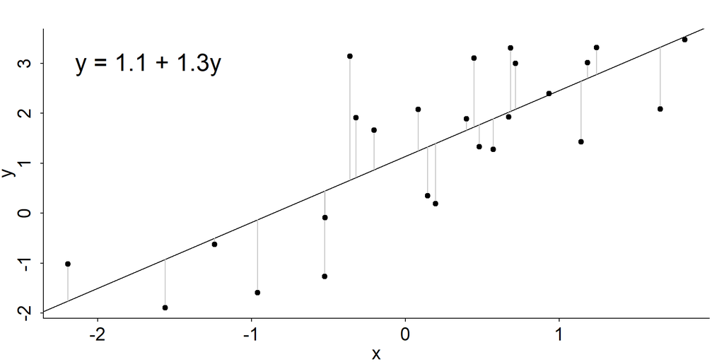

## Nonparametric estim. of the conditional mean

- Nonparametric models do not assume a functional form
  - each conditional mean has its own “parameter”

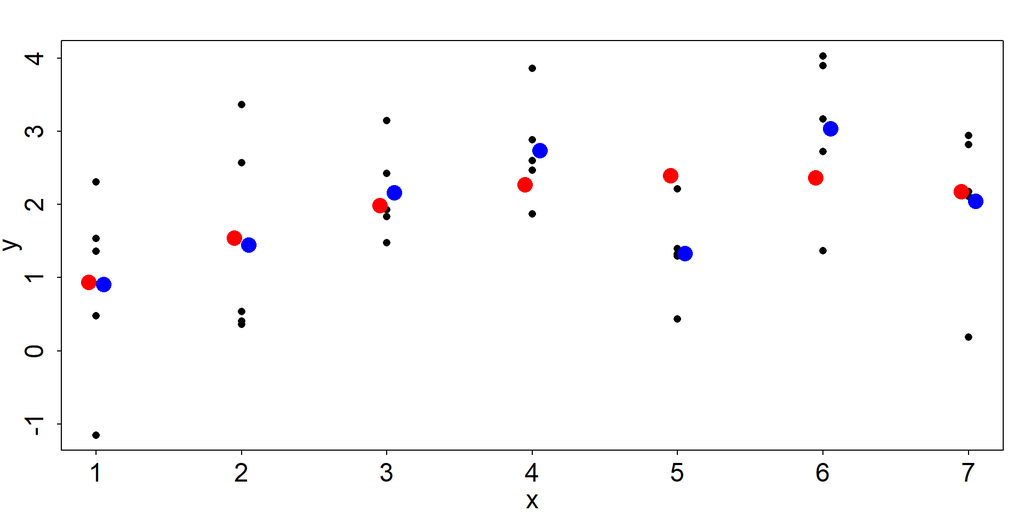

## Smoothing

- *linear and non-parametric models are extremes on a continuum*
  - on one end the expected outcome for a treatment level depends on the outcomes observed at all treatment levels
  - on the other end the expected outcome depends only on the outcomes observed at the focal treatment levels

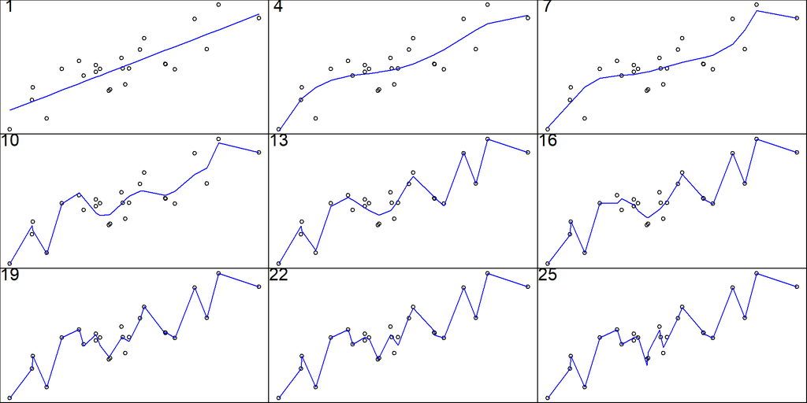

## Non-linear relationships from “linear models”

We can model non-linear relationships by using modified predictors for the linear model”

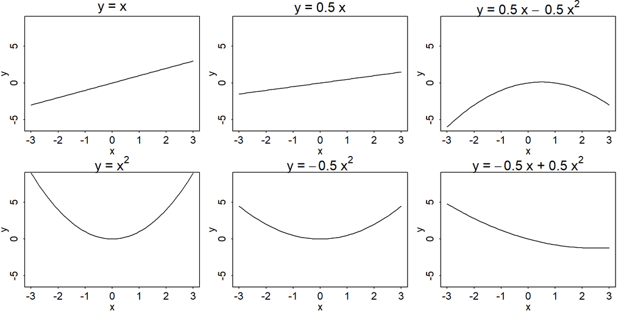

## Modern statistics/ML estimates smoothness

Penalized splines use a penalty term to discount the fit of flexible models

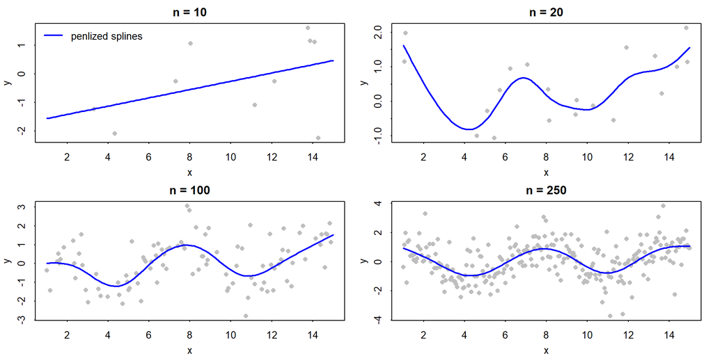

## Old statistics does not

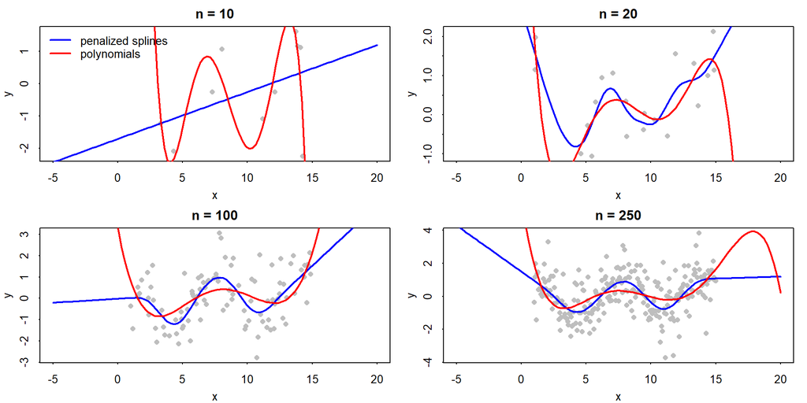

## Bias-variance trade-off

$$\begin{align}
MSE &= \mathbb{E}[(y-\hat{y})^2] \\
MSE &= bias + variance + \sigma^2 \\
bias &= \mathbb{E}[y]-\mathbb{E}[\hat{y}] \\
variance &= \mathbb{E}[(\mathbb{E}[\hat{y}]-\hat{y})^2]
\end{align}$$

- $MSE$ = **total error**:  
  mean squared error between observed and predicted values
- $bias$ = difference between the true and predicted mean
- $variance$ = variability of predicted means over data samples

## $Bias$-variance trade-off

Difference between the true and predicted mean

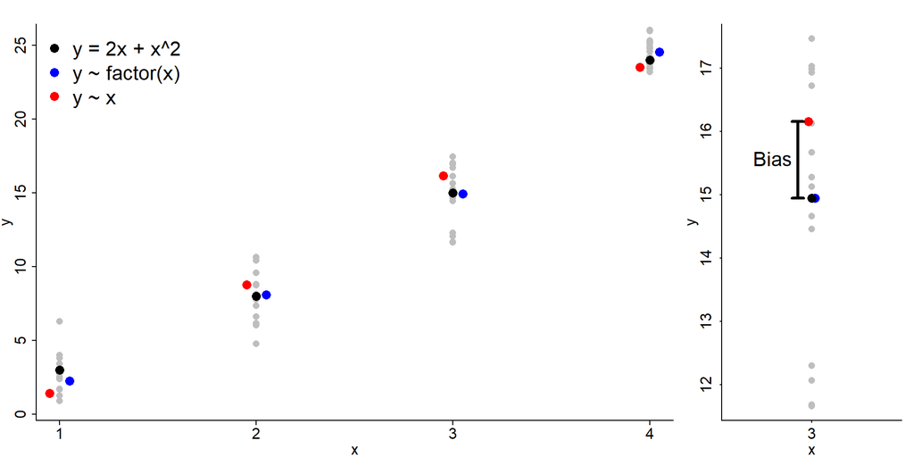

## Bias-$variance$ trade-off

Variability (standard error) of predicted means over samples.

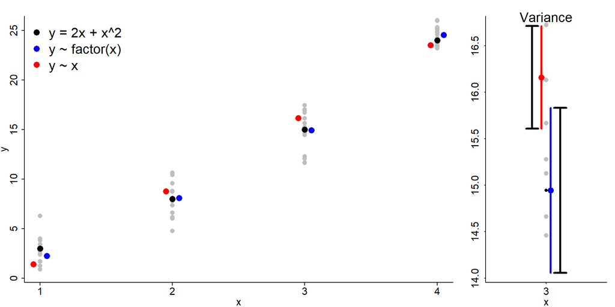

## Bias-variance trade-off

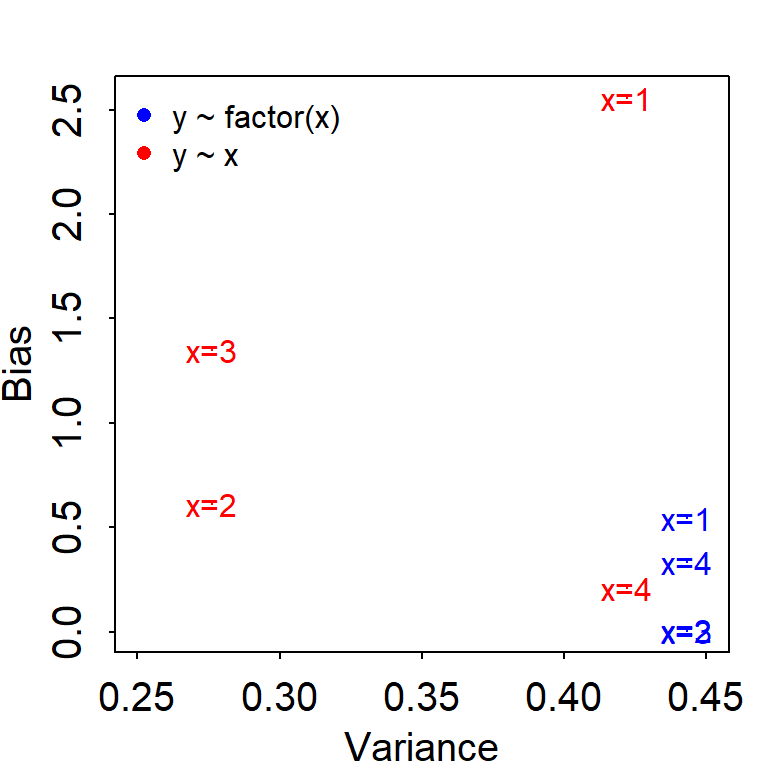

## Identifying the “right” model

- the use of machine learning in causal inference is built on the idea the flexible ML models can reduce bias, while avoiding high variance
- personally, I doubt that using ML models out of the box (without expertedly tuning hyper parameters) is the best path to finding the “best” model
- instead, combining domain knowledge with fitting flexible regularized models and state of the are model comparison or model averaging are provide better guarantees to identify models that neither over- nor underfit the data.

## The generalised linear model

- Different types of data require different likelihood functions
  - distributions that describe data from different (partially) random processes
- The means of some likelihood functions are restricted, which required link functions

## Logistic regression for binary outcomes

linear model:

$lp_i = \alpha + \beta_1 x_i + \beta_2 x_i^2 + ...$

**restriction**

$0 < p < 1$

**logistic** link function:

$p_i = exp(lp_i) / (1 + exp(lp_i))$

**Binomial** likelihood $L_i = binomial(y_i, p_i)$

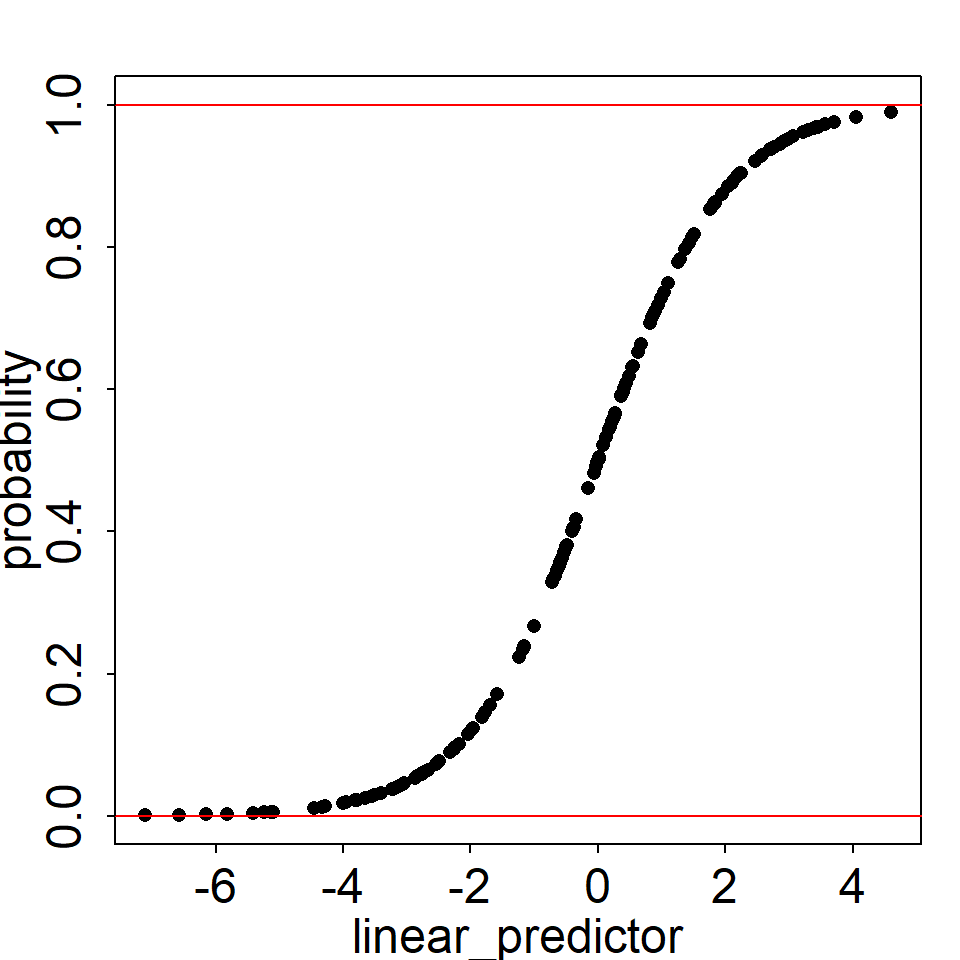

## Poisson regression for counts

linear model:

$lp_i = \alpha + \beta_1 x_i + \beta_2 x_i^2 + ...$

**restriction**

$\mu \geq 0$

**log** link function:

$\mu_i = exp(lp_i)$

**Poisson** likelihood $L_i = poisson(y_i, \mu_i)$

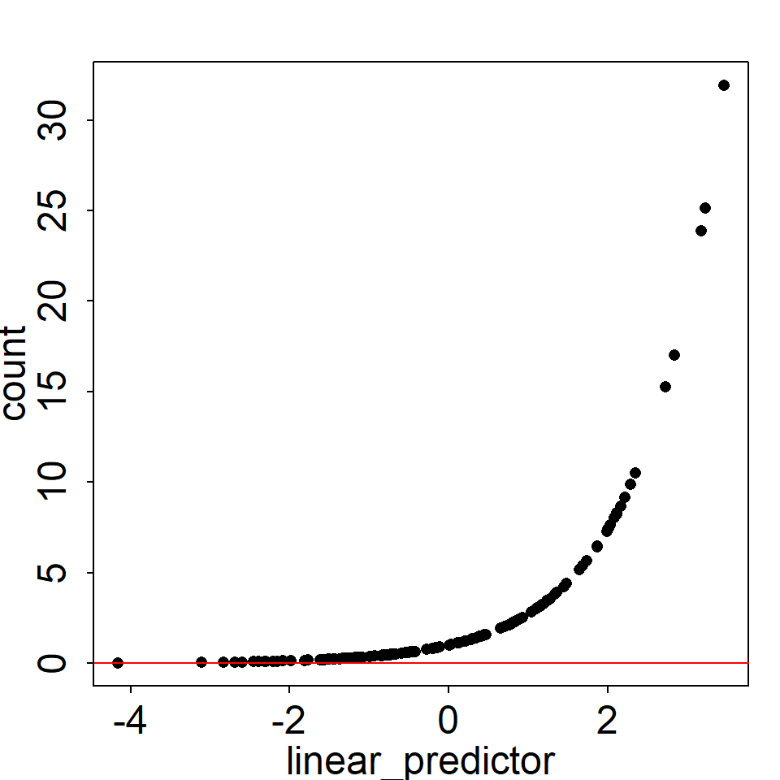